# Отчет по лабораторной работе №10

Отчет по лабораторной работе Управление модулями ядра из командной строки

Чилеше . Л

Российский университет дружбы народов, Москва, Россия

Объединённый институт ядерных исследований, Дубна, Россия

# Информация

## Докладчик

- Лупупа Чилеше
- Студент
- Студент Группы НПИбд-03-23
- Российский университет дружбы народов

# Вводная часть

## Цель работ

Цель данной лабораторной работы заключается в изучении управления модулями ядра Linux с помощью командной строки. В рамках работы необходимо ознакомиться с командами для просмотра, загрузки и выгрузки модулей ядра, а также с обновлением ядра операционной системы.

## lspci -k

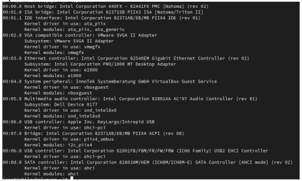

Команда отобразила список всех устройств PCI в системе и соответствующих драйверов ядра

## lsmod | sort

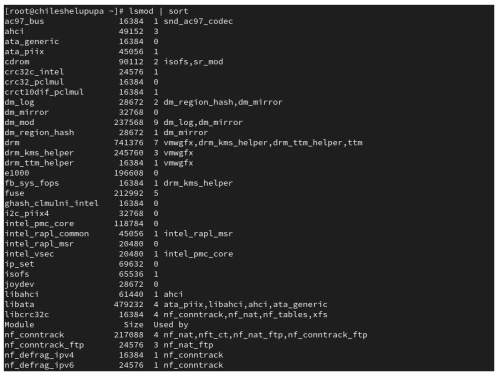

Вывод показал список загруженных модулей, отсортированный по алфавиту.

## lsmod | grep ext4

Если модуль не загружен, в выводе ничего не отображается.

# Загрузка и выгрузка модулей

## lsmod | grep ext4`

[figure not shown]

## modinfo ext4

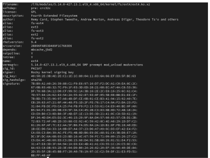

Вывод команды содержит сведения о версии, лицензии, описании модуля и поддерживаемых устройствах. Обратите внимание, что у данного модуля нет параметров настройки.

## modprobe -r ext4

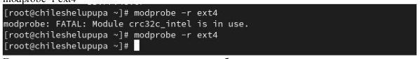

Если модуль используется, система может потребовать повторного выполнения команды или отказать в выгрузке

# Работа с Bluetooth-модулями

- Проверка, загружен ли модуль bluetooth: lsmod | grep bluetooth
- Загрузка модуля bluetooth: modprobe bluetooth
- Просмотр списка модулей, связанных с Bluetooth: lsmod | grep bluetooth

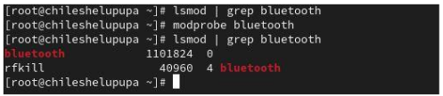

## modinfo bluetooth

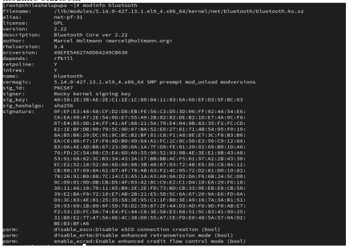

## modprobe -r bluetooth

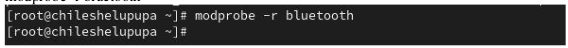

# Обновление ядра системы

Rocky Linux является дистрибутивом, базирующимся на RHEL, поэтому обновление ядра проходит стабильно.

## uname -r

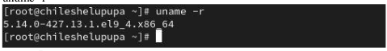

## dnf list kernel

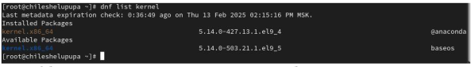

## Выводы

В ходе лабораторной работы были освоены команды управления модулями ядра: просмотр, загрузка, выгрузка и получение информации. Также была выполнена процедура обновления ядра операционной системы. Полученные знания позволяют администрировать систему на более глубоком уровне и эффективно управлять модулями ядра.